# Introdução à economia

Aula 25 - O sistema monetário

Prof. Roberto de Freitas Neder

## Aula 25: roteiro

**O sistema monetário** · Mankiw, capítulo 29 · UnB

- Moeda, funções e evolução
- Agregados monetários e base
- Instituições brasileiras
- Bancos e criação de depósitos
- Multiplicador simples e geral
- Capital, alavancagem e crises
- Instrumentos e Selic
- Conclusão
- Exercícios de concursos públicos

Use as setas para trocar de slide e a rolagem nas páginas longas. Os exemplos numéricos são hipotéticos, salvo indicação expressa. As respostas ficam fechadas até o clique.

## 01 - De onde vem o dinheiro que usamos?

Uma família recebe salário, paga compras por Pix e guarda parte da renda. Uma empresa toma crédito para comprar máquinas. Um banco concede o empréstimo e o Banco Central altera a Selic.

**Como essas decisões se conectam?** A moeda permite pagamentos; os bancos criam depósitos; o Banco Central influencia as condições de liquidez e o custo do crédito.

Nesta aula, vamos reconstruir esses mecanismos por meio de conceitos, balanços e cálculos em reais. O objetivo é compreender tanto o modelo do capítulo quanto seus limites na economia brasileira.

**Leitura:** Mankiw, *Principles of Economics*, 8ª edição, capítulo 29, pp. 603 a 626. O conteúdo teórico termina na p. 622.

← Menu

## 02 - Moeda, renda e riqueza não são sinônimos

| Conceito | O que mede | Exemplo didático |
| --- | --- | --- |
| Moeda | Estoque de ativos aceitos nos pagamentos | R$ 500 em espécie e R$ 1.500 em conta à vista |
| Renda | Fluxo recebido em um período | Salário de R$ 4.000 por mês |
| Riqueza líquida | Ativos menos dívidas, em uma data | Imóvel, aplicações e dinheiro, descontado o financiamento |

Uma pessoa pode ter patrimônio elevado e pouco dinheiro disponível. Outra pode receber renda alta e acumular dívidas.

**Estoque tem data; fluxo tem intervalo de tempo.** O PIB é um fluxo anual ou trimestral. A quantidade de moeda é um estoque.

← Menu

## 03 - Por que a moeda facilita as trocas?

No escambo, uma professora que oferece aulas e deseja arroz precisa encontrar alguém que tenha arroz e queira aulas. Essa exigência é a **dupla coincidência de desejos**.

Com moeda, a professora pode vender aulas a uma pessoa e comprar arroz de outra. Compra e venda ficam separadas no tempo e entre diferentes agentes.

Isso reduz custos de procura e negociação, favorecendo especialização e divisão do trabalho. A confiança na aceitação do meio de pagamento sustenta o processo.

O escambo é um contraste analítico útil. A história monetária concreta também envolve crédito, dívidas, tributos e instituições; não segue uma única sequência universal.

← Menu

## 04 - As três funções da moeda

| Função | Pergunta que resolve | Exemplo brasileiro |
| --- | --- | --- |
| Meio de troca | Com que instrumento quitamos a compra? | Pagamento em reais, em espécie ou por transferência de depósito |
| Unidade de conta | Em que medida comparamos valores? | Arroz a R$ 30, aluguel a R$ 1.500 e salário em reais |
| Reserva de valor | Como transferimos poder de compra no tempo? | Manter saldo para pagar uma conta na próxima semana |

A moeda não é a única reserva de valor. Imóveis e títulos também podem cumprir essa função, mas têm diferentes riscos e graus de liquidez.

**Uma mesma moeda pode cumprir mal uma função e continuar sendo usada nas outras.** Inflação elevada enfraquece sua capacidade de preservar poder de compra.

← Menu

## 05 - Unidade de conta e preços relativos

Sem uma unidade comum, cada bem precisa ser cotado em outros bens. Com $n$ mercadorias, existem $n(n-1)/2$ relações bilaterais de troca.

Com 10 mercadorias, são 45 relações. Uma unidade monetária permite anunciar os 10 preços numa escala comum e calcular os preços relativos a partir deles.

Se um livro custa R$ 60 e uma refeição custa R$ 30, o preço relativo do livro é **duas refeições**. O real mede os valores; o custo de oportunidade continua sendo real.

Contratos, salários, balanços e tributos também precisam de uma unidade de conta para tornar obrigações comparáveis.

← Menu

## 06 - Liquidez, rendimento e poder de compra

**Liquidez** é a facilidade de converter um ativo em meio de pagamento, rapidamente e sem perda relevante de valor. A moeda usada nos pagamentos é o ativo de referência.

Manter dinheiro disponível oferece conveniência, mas pode significar abrir mão de juros. Esse rendimento perdido é um **custo de oportunidade**.

Exemplo: R$ 100 compram dez refeições de R$ 10. Se o preço passa a R$ 12, os mesmos R$ 100 compram aproximadamente 8,33 refeições.

O saldo nominal não mudou; seu poder de compra caiu. A relação geral é $M/P$, em que $P$ representa o nível de preços. Aqui, $P$ não é a notação de papel-moeda que usaremos adiante.

← Menu

## 07 - Tipos de moeda: o que sustenta a aceitação?

| Tipo | Característica | Exemplo |
| --- | --- | --- |
| Moeda-mercadoria | Tem utilização ou valor fora da função monetária | Ouro ou uma mercadoria aceita em trocas |
| Representativa e conversível | Promete conversão em um ativo de referência | Nota historicamente conversível em metal |
| Fiduciária | Não exige conversão em mercadoria a uma taxa fixa | Real contemporâneo |

O valor da moeda fiduciária depende de instituições, aceitação social, capacidade de cumprir obrigações e confiança em seu poder de compra.

**Curso legal não elimina a necessidade de confiança.** Uma moeda pode continuar obrigatória em certas relações e sofrer forte perda de valor.

← Menu

## 08 - Uma história de formas que coexistem

Mercadorias, metais, moedas cunhadas, notas e depósitos ajudaram a resolver problemas de transporte, divisibilidade, reconhecimento e segurança.

No território brasileiro, registros históricos incluem uso monetário de açúcar, fumo, tecidos de algodão e conchas, ao lado de diferentes moedas metálicas. As formas não substituíram umas às outras de maneira uniforme.

Notas tornaram pagamentos mais transportáveis; registros bancários permitiram transferir direitos sobre depósitos; sistemas eletrônicos aceleraram as transferências.

**Mudar o suporte do pagamento não implica criar uma nova unidade monetária.** Uma nota, um saldo bancário e um pagamento eletrônico podem continuar denominados em reais.

Fonte: [BCB, O dinheiro no Brasil](https://www.bcb.gov.br/Pre/PEF/PORT/publicacoes_DinheironoBrasil.pdf).

← Menu

## 09 - O Plano Real e a separação das funções

No Plano Real, a **Unidade Real de Valor, URV**, funcionou como referência para expressar preços, enquanto os pagamentos continuaram em cruzeiros reais, convertidos pela cotação diária.

A URV operou de março a junho de 1994. O real entrou em circulação em 1º de julho de 1994: uma URV correspondia a um real, convertido a CR$ 2.750 naquele momento.

O caso permite separar **unidade de conta** e **meio de troca**. Antes do real físico, já existia uma referência de preços que não era uma cédula usada nas compras.

O programa foi mais amplo que a troca de nome da moeda. Envolveu uma estratégia de estabilização e reorganização da formação de preços.

Fonte: [BCB, Plano Real](https://www.bcb.gov.br/controleinflacao/planoreal).

← Menu

## 10 - Moeda física, escritural e pagamento eletrônico

**Moeda manual:** cédulas e moedas metálicas em circulação. **Moeda escritural:** depósitos à vista que podem ser transferidos para realizar pagamentos.

O depósito é um ativo do correntista e uma obrigação do banco. Não é necessário que cada real depositado corresponda a uma cédula separada em um cofre.

O Pix é um arranjo de pagamentos instantâneos: permite movimentar recursos entre contas. **Pix não é uma moeda diferente do real.**

Contas bancárias e contas de pagamento têm enquadramentos distintos. Ser acessível por aplicativo não informa, sozinho, a natureza jurídica do saldo nem sua classificação estatística.

Fonte: [BCB, Pix](https://bcb.gov.br/estabilidadefinanceira/pix-sobre).

← Menu

## 11 - Cartão, cheque e aplicativo são moeda?

| Instrumento | O que acontece |
| --- | --- |
| Cartão de débito | Transfere recursos disponíveis em conta |
| Cheque | Dá uma ordem de pagamento sobre um depósito |
| Pix | Executa uma transferência entre contas |
| Cartão de crédito | Permite uma compra com obrigação de pagamento posterior |

O cartão não é contado como um estoque monetário independente. No débito, o ativo usado é o saldo; no crédito, surge uma dívida que depois será liquidada.

Cartões de crédito podem reduzir a necessidade de carregar dinheiro. Isso afeta a **demanda por moeda**, sem tornar o limite do cartão equivalente a dinheiro já depositado.

← Menu

## 12 - Quanto dinheiro existe? Primeiro, definir a medida

Não basta somar tudo que alguém chama de dinheiro. Precisamos escolher quais ativos, emissores e detentores entram no conceito.

**M1**, a medida restrita, reúne papel-moeda em poder do público e depósitos à vista. Medidas amplas acrescentam ativos financeiros com características diferentes de liquidez.

Transferir R$ 1.000 de conta à vista para poupança reduz M1, mas não necessariamente reduz M2. Houve mudança de composição, sem destruição equivalente da riqueza financeira da pessoa.

Também precisamos especificar a data e o método de apuração. Comparar saldo de fim de mês com média mensal pode produzir conclusões equivocadas.

Fonte: [BCB, Panorama das sociedades de depósitos](https://www.bcb.gov.br/estatisticas/panoramaosd).

← Menu

## 13 - M1: a moeda usada diretamente nas transações

Usaremos $P$ para **papel-moeda em poder do público**, incluindo moedas metálicas, e $D$ para **depósitos à vista**.

$$M_1=P+D$$

Exemplo: se o público mantém R$ 200 milhões em espécie e R$ 800 milhões em depósitos à vista, $M_1=R\$\ 1.000$ milhões.

Dinheiro no caixa dos bancos não está em poder do público. Somá-lo novamente a M1 produziria dupla contagem ou mistura de conceitos.

Na notação desta parte da aula, **$P$ é numerário do público, não nível de preços**. Todas as grandezas do exemplo são estoques na mesma data.

← Menu

## 14 - M2, M3 e M4 no Brasil

| Agregado | Acréscimos em relação ao anterior |
| --- | --- |
| M1 | Numerário do público e depósitos à vista |
| M2 | M1 + depósitos de poupança + títulos privados de instituições depositárias |
| M3 | M2 + quotas de fundos de investimento depositários + operações compromissadas com títulos públicos e privados |
| M4 | M3 + títulos públicos federais em poder do público |

Esta é uma síntese da metodologia brasileira. Os agregados são **consolidados**: não se somam indiscriminadamente carteiras de fundos e quotas dos mesmos fundos.

A composição brasileira difere da americana e foi revisada ao longo do tempo. Em provas antigas, observe a definição e o período do enunciado.

Fonte: [BCB, metodologia e séries dos agregados](https://www.bcb.gov.br/estatisticas/panoramaosd).

← Menu

## 15 - Base monetária: a moeda do Banco Central

Defina $R$ como as reservas bancárias: numerário em caixa e saldos de reservas no Banco Central, dentro do modelo adotado.

$$B=P+R\qquad M_1=P+D$$

O BCB apresenta a base restrita como papel-moeda emitido em circulação mais reservas bancárias em suas contas. Como o numerário emitido inclui os caixas bancários, as duas formas se reconciliam ao separar público e bancos.

**Base e M1 têm emissores e componentes distintos.** Reservas são usadas pelos bancos; depósitos à vista são usados pelo público. Não se deve somar $B+M_1$ para medir a moeda total.

Fontes: [BCB, Panorama do Banco Central](https://www.bcb.gov.br/estatisticas/panoramabc) e [glossário](https://www.bcb.gov.br/meubc/glossario).

← Menu

## 16 - Um mesmo total, diferentes componentes

Considere $P=200$, $D=800$ e $R=200$, em milhões de reais. Então $M_1=1.000$ e $B=400$.

O público deposita R$ 100 milhões em espécie. Imediatamente, $P$ cai para 100, $D$ sobe para 900 e o caixa dos bancos aumenta $R$ para 300.

$$M_1=100+900=1.000\qquad B=100+300=400$$

**O depósito inicial apenas mudou a composição.** Não criou, sozinho, moeda adicional. A expansão posterior de crédito e depósitos é outra etapa, sujeita a condições que vamos examinar.

O saque faz o movimento inverso: troca depósito por numerário, sem necessariamente alterar M1 naquele instante.

← Menu

## 17 - Quem faz o quê no Brasil?

| Instituição | Papel nesta aula |
| --- | --- |
| Conselho Monetário Nacional, CMN | Diretrizes monetárias e financeiras; fixa a meta de inflação |
| Banco Central do Brasil, BCB | Executa a política monetária, emite moeda, atua na estabilidade e supervisão financeira |
| Copom | Colegiado do BCB que define a meta para a taxa Selic |
| Tesouro Nacional | Administração financeira e da dívida pública federal |
| Bancos comerciais e múltiplos habilitados | Depósitos, crédito e pagamentos |

O Banco do Brasil é uma instituição bancária, não o Banco Central. A Casa da Moeda fabrica numerário; a decisão de emissão e gestão da circulação pertence ao BCB.

Fontes: [BCB, institucional](https://www.bcb.gov.br/acessoinformacao/institucional/) e [caminho do dinheiro](https://www.bcb.gov.br/cedulasemoedas/caminhododinheiro/).

← Menu

## 18 - Banco Central: origem, funções e autonomia

O BCB foi criado pela Lei nº 4.595, de dezembro de 1964, e iniciou suas atividades em 1965. Antes, funções monetárias estavam distribuídas entre instituições como Sumoc, Tesouro e Banco do Brasil.

A autonomia definida pela Lei Complementar nº 179/2021 inclui mandatos e autonomia técnica, operacional, administrativa e financeira. **Autonomia não significa ausência de objetivos legais ou de prestação de contas.**

O objetivo fundamental é assegurar a estabilidade de preços. Sem prejuízo dele, a lei também atribui objetivos de estabilidade e eficiência do sistema financeiro, suavização das flutuações da atividade e fomento do pleno emprego.

Fontes: [BCB, autonomia](https://www.bcb.gov.br/acessoinformacao/autonomia) e [Sumoc](https://www.bcb.gov.br/acessoinformacao/sumoc).

← Menu

## 19 - Meta de inflação e meta de juros são diferentes

O **CMN fixa a meta de inflação**. O **Copom, integrado pelo presidente e diretores do BCB, define a meta Selic**, instrumento para buscar aquela meta.

Desde 2025, a meta de inflação é contínua: refere-se ao IPCA acumulado em 12 meses, apurado mensalmente. O centro é 3%, com tolerância de 1,5 ponto percentual para cada lado; o critério de descumprimento considera seis meses consecutivos fora do intervalo.

A meta não é um comando que fixa cada preço. O BCB tenta influenciar demanda, crédito e expectativas. Seus efeitos levam tempo e não eliminam choques de oferta.

Fontes: [BCB, histórico de metas](https://bcb.gov.br/controleinflacao/historicometas) e [Copom](https://www.bcb.gov.br/controleinflacao/copom). Referência institucional consultada em 06/11/2026.

← Menu

## 20 - Um balanço simplificado do Banco Central

| Ativos | Passivos e patrimônio |
| --- | --- |
| Reservas internacionais | Numerário emitido |
| Títulos em carteira | Saldos dos bancos no BCB |
| Créditos a instituições financeiras | Depósitos do Tesouro e outras obrigações |
| Outros ativos | Patrimônio líquido e ajustes |

As reservas internacionais são **ativos do BCB**. As reservas dos bancos mantidas no BCB são **obrigações do BCB perante essas instituições**. O nome parecido não torna os conceitos iguais.

Nem todo passivo do BCB faz parte da base restrita. O quadro destaca categorias; não pretende reproduzir todas as rubricas de seu balanço contábil.

← Menu

## 21 - Emitir moeda não é apenas imprimir cédulas

Substituir uma nota desgastada por outra de mesmo valor não aumenta, por si só, o estoque de moeda. Imprimir e guardar notas ainda não colocadas em circulação também não equivale a disponibilizá-las ao público.

O BCB pode criar saldos de reservas eletronicamente, por exemplo ao adquirir um ativo e creditar a conta de uma instituição financeira, conforme a operação.

A compra altera dois lados do balanço: **aumenta um ativo e aumenta uma obrigação monetária**. A venda pode realizar o movimento inverso.

O efeito sobre depósitos do público depende da contraparte e das etapas da transação. Aumento de reservas bancárias não é automaticamente aumento de M1 na mesma proporção.

← Menu

## 22 - Como ler o balanço de um banco

$$\text{Ativos}=\text{Passivos}+\text{Patrimônio líquido}$$

| Ativos: usos dos recursos | Passivos e patrimônio: financiamento |
| --- | --- |
| Reservas e caixa | Depósitos dos clientes |
| Empréstimos concedidos | Dívidas com outras instituições |
| Títulos e outros ativos | Capital e resultados acumulados |

Para o cliente, o depósito é um direito. Para o banco, é uma obrigação. Um empréstimo é um ativo do banco porque dá direito a receber pagamentos do devedor.

**Reserva é um ativo líquido; capital é patrimônio que absorve perdas.** Essas categorias não são intercambiáveis.

← Menu

## 23 - O modelo de reservas de 100%

Imagine um sistema que apenas guarda depósitos à vista e mantém integralmente esses valores em reservas, sem conceder crédito a partir deles.

Uma família deposita R$ 1.000 em espécie:

| Banco A: ativos | Banco A: passivos |
| --- | --- |
| Reservas: R$ 1.000 | Depósito da família: R$ 1.000 |

Antes, a família tinha R$ 1.000 em espécie; depois, tem R$ 1.000 em depósito. **M1 permanece R$ 1.000.**

Esse é um modelo de referência para isolar o papel dos bancos na criação de moeda, não uma descrição de todas as formas possíveis de financiamento bancário.

← Menu

## 24 - Reservas fracionárias: a hipótese do capítulo

Agora admita que o banco mantenha 20% dos depósitos em reservas e conceda crédito com o restante, dentro do modelo simplificado.

Após um empréstimo de R$ 800 ser gasto e liquidado para outra instituição:

| Banco A: ativos | Banco A: passivos |
| --- | --- |
| Reservas: R$ 200 | Depósito inicial: R$ 1.000 |
| Empréstimo: R$ 800 |  |

O depositante original conserva seu direito de R$ 1.000. O empréstimo permitiu que outra pessoa obtivesse poder de compra e gerasse um novo depósito no sistema.

**20% é uma hipótese didática**, não uma informação sobre a alíquota legal vigente no Brasil. O modelo ainda supõe ausência de perdas, de vazamentos em espécie e de reservas excedentes.

← Menu

## 25 - O instante da concessão: crédito cria depósito

Considere um crédito de R$ 800, lançado na conta do tomador no próprio Banco A. A variação inicial do balanço é:

| Ativos | Passivos |
| --- | --- |
| Empréstimos: + R$ 800 | Depósitos: + R$ 800 |

Não é necessário retirar R$ 800 do saldo de outro correntista. O banco registra simultaneamente um direito contra o devedor e uma obrigação perante o titular da conta.

**Criar depósito não elimina a necessidade de financiar e liquidar pagamentos.** O cliente pode transferir esse saldo para outro banco, exigindo reservas. Capital, risco, rentabilidade, regulação e demanda de crédito limitam o processo.

Complemento: [Banco da Inglaterra, Money creation in the modern economy](https://www.bankofengland.co.uk/quarterly-bulletin/2014/q1/money-creation-in%20the-modern-economy).

← Menu

## 26 - Quando o dinheiro vai para outro banco

O tomador usa os R$ 800 para pagar um fornecedor que mantém conta no Banco B.

| Variação | Banco A | Banco B |
| --- | --- | --- |
| Depósitos | − R$ 800 | + R$ 800 |
| Reservas de liquidação | − R$ 800 | + R$ 800 |

O empréstimo continua no ativo do Banco A. O depósito agora está no Banco B. As reservas mudam de instituição, mas seu total no sistema não aumenta nessa transferência.

**O público paga com depósitos; bancos liquidam entre si com moeda de banco central.** Reservas não são simplesmente entregues às famílias como se fossem suas contas correntes.

← Menu

## 27 - A cadeia de depósitos no modelo simplificado

Com retenção de 20% e redepósito integral dos recursos recebidos:

| Rodada | Novo depósito | Reserva de 20% | Crédito de 80% |
| --- | --- | --- | --- |
| A | R$ 1.000,00 | R$ 200,00 | R$ 800,00 |
| B | R$ 800,00 | R$ 160,00 | R$ 640,00 |
| C | R$ 640,00 | R$ 128,00 | R$ 512,00 |
| D | R$ 512,00 | R$ 102,40 | R$ 409,60 |
| Demais | Valores decrescentes | Valores decrescentes | Valores decrescentes |

Cada rodada é menor que a anterior. A expansão é limitada pela retenção de reservas. Não estamos supondo que o mesmo banco possa emprestar indefinidamente sem liquidez ou capital.

← Menu

## 28 - Somando a expansão: por que aparece 1/r?

Se $r=R/D$ é a proporção de reservas e a entrada inicial de reservas é $R_0$:

$$D=R_0+(1-r)R_0+(1-r)^2R_0+\cdots$$
$$D=\frac{R_0}{1-(1-r)}=\frac{R_0}{r}$$

Com $R_0=1.000$ e $r=0{,}20$:

$$D=5.000\qquad R=1.000\qquad L=D-R=4.000$$

$L$ representa os empréstimos adicionais no modelo. O multiplicador simples é $1/r=5$. A soma de infinitas rodadas é **finita** porque a razão da progressão geométrica é menor que um.

← Menu

## 29 - As rodadas convergem, não explodem

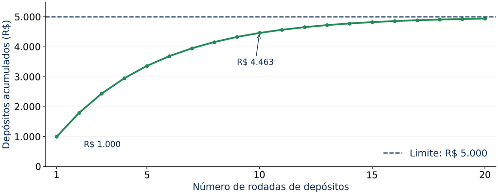

Depósitos acumulados convergem a R$ 5.000 quando cada rodada retém 20% em reservas.

O primeiro depósito é R$ 1.000. Após dez rodadas, o acumulado é aproximadamente R$ 4.463. O limite é R$ 5.000, não um valor alcançado instantaneamente na prática.

**Figura autoral:** trajetória matemática do modelo, sem dados observados do sistema bancário brasileiro.

← Menu

## 30 - O cuidado com a variação inicial

Há duas perguntas diferentes, mesmo quando o sistema termina com R$ 5.000 em depósitos:

| Origem dos R$ 1.000 | Efeito inicial | Expansão final de M1 no exemplo |
| --- | --- | --- |
| Numerário que o público já possuía | Apenas troca espécie por depósito | R$ 4.000, além dos R$ 1.000 preexistentes |
| Nova base que sustenta expansão de depósitos, partindo da situação marginal do modelo | Aumenta os recursos monetários de base | Até R$ 5.000, com as hipóteses mantidas |

No primeiro caso, o dinheiro inicial **já estava em M1**. Somar o depósito inicial como criação adicional contaria duas vezes o mesmo valor.

Sempre identifique o estoque inicial, a operação e o conceito solicitado.

← Menu

## 31 - Pagamento do principal destrói moeda bancária

Um devedor paga R$ 300 do principal de seu empréstimo usando um depósito no próprio banco.

| Ativos do banco | Passivos do banco |
| --- | --- |
| Empréstimos: − R$ 300 | Depósitos: − R$ 300 |

O crédito e o depósito diminuem juntos. Houve destruição de moeda escritural, sem destruição física de notas.

Se o pagamento vem de outro banco, a liquidação inclui transferência de reservas, mas a redução agregada de depósitos associada à amortização permanece.

**Juros não são principal:** remuneram o banco e afetam seu resultado. Seus efeitos sobre depósitos dependem também de como o banco paga despesas e distribui renda.

← Menu

## 32 - Criar moeda não cria riqueza real automaticamente

Ao conceder um crédito, o banco cria um depósito e uma dívida. O tomador ganha liquidez, mas também uma obrigação de pagamento.

O país não recebe automaticamente mais máquinas, moradias ou alimentos porque o saldo nominal aumentou. O efeito real depende do uso dos recursos e das condições de oferta.

Crédito para um projeto viável pode financiar produção, emprego e produtividade. Crédito mal avaliado pode financiar ativos de baixa qualidade, perdas e fragilidade financeira.

**Conexão com o curso:** a intermediação ajuda a direcionar recursos, mas envolve assimetria de informação, seleção adversa, risco moral e externalidades quando problemas se espalham pelo sistema.

← Menu

## 33 - O multiplicador com moeda nas mãos do público

Agora permita que o público mantenha parte de seus recursos em espécie. Defina:

$$c=\frac{P}{D}\qquad r=\frac{R}{D}$$
$$M_1=P+D=(1+c)D\qquad B=P+R=(c+r)D$$
$$m=\frac{M_1}{B}=\frac{1+c}{c+r}$$

O multiplicador $1/r$ aparece como caso particular quando $c=0$. Usamos o mesmo denominador, depósitos, em ambas as razões.

$r$ pode ser decomposto em reserva exigida no modelo e reserva excedente. Na realidade brasileira, bases de incidência e instrumentos são mais variados que essa representação.

← Menu

## 34 - Exemplo completo com retenção de numerário

Considere $B=R\$\ 1.000$, $c=0{,}25$ e $r=0{,}20$.

$$m=\frac{1{,}25}{0{,}45}\approx2{,}7778\qquad M_1\approx2.777{,}78$$

| Componente | Cálculo | Valor aproximado |
| --- | --- | --- |
| Depósitos | $D=B/(c+r)$ | R$ 2.222,22 |
| Espécie com o público | $P=cD$ | R$ 555,56 |
| Reservas | $R=rD$ | R$ 444,44 |

Conferência: $P+R=1.000$ e $P+D=2.777{,}78$. Arredondamentos podem produzir diferenças de centavos.

A mesma base sustenta menos depósitos quando uma parcela fica em numerário fora dos bancos.

← Menu

## 35 - Quando a questão usa D/M1 em vez de P/D

Algumas provas definem $d=D/M_1$, a participação dos depósitos nos meios de pagamento. Assim, $P=(1-d)M_1$ e $R=rdM_1$.

$$B=[1-d+rd]M_1\qquad m=\frac{1}{1-d+rd}$$

Se depósitos são 80% de M1, $d=0{,}80$. Logo $c=P/D=0{,}20/0{,}80=0{,}25$, e não 0,20.

Com $r=0{,}20$:

$$m=\frac{1}{0{,}20+0{,}16}=2{,}7778$$

As fórmulas são equivalentes. O erro costuma estar em transportar um percentual para uma razão com **denominador diferente**.

← Menu

## 36 - O que reduz o multiplicador?

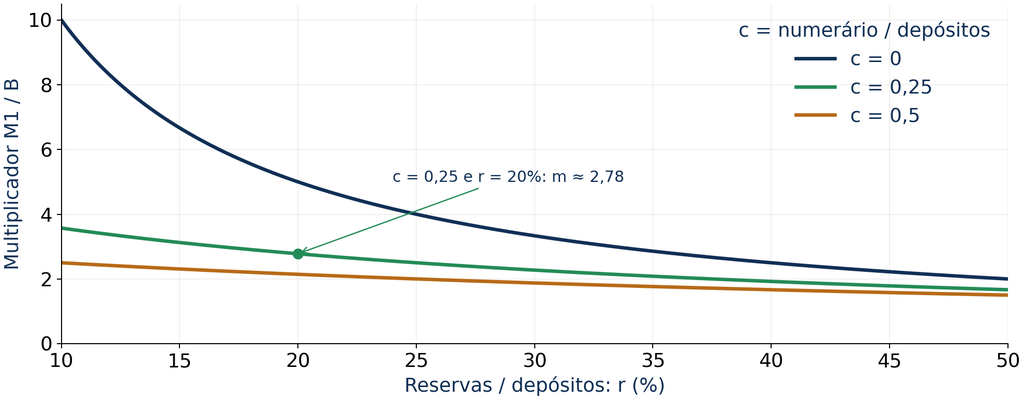

Quanto maiores as razões de reservas e de numerário, menor o multiplicador no domínio representado.

Para $0<r<1$, mantendo as demais condições, mais numerário relativo aos depósitos ou mais reservas relativas aos depósitos reduzem $m$.

Isso é uma comparação entre configurações do modelo. Não demonstra que o crédito brasileiro responda mecanicamente a uma alteração isolada da base.

← Menu

## 37 - Uma identidade não é uma previsão automática

$$M_1=mB$$

Como definição contábil, a igualdade vale se $m=M_1/B$. Para prever que dobrar $B$ dobra $M_1$, seria necessário supor **$m$ constante** e explicar o mecanismo de ajuste.

Em uma crise, bancos podem preferir liquidez, tomadores podem não querer crédito e a percepção de risco pode crescer. Nesse caso, a base pode aumentar sem expansão proporcional dos depósitos e do gasto.

O BCB divulga um multiplicador observado como relação entre M1 e base. Ele descreve a composição monetária; não deve ser confundido com uma máquina de crédito de coeficiente fixo.

Fonte: [BCB, série do multiplicador monetário](https://dadosabertos.bcb.gov.br/dataset/7534-sgs).

← Menu

## 38 - Por que um banco não cria crédito sem limite?

| Restrição | Por que importa |
| --- | --- |
| Capital | Perdas precisam ser absorvidas por patrimônio adequado |
| Liquidez e captação | Pagamentos podem sair para outros bancos |
| Risco de crédito | Nem todo empréstimo será recuperado |
| Rentabilidade | Receita esperada precisa compensar custos e riscos |
| Regulação e supervisão | Impõem critérios prudenciais e condições de operação |
| Demanda solvente | É necessário encontrar tomadores e projetos financiáveis |

No sistema contemporâneo, a concessão pode iniciar com a criação do depósito; o banco precisa gerir as consequências de liquidez e financiamento. A Selic altera o custo dessas decisões.

← Menu

## 39 - Capital bancário: quem absorve as perdas?

Um banco hipotético tem R$ 1.000 em ativos, R$ 950 em dívidas e depósitos e R$ 50 de patrimônio líquido.

$$A=1.000\qquad Passivos=950\qquad PL=50$$

Se empréstimos perdem R$ 30 de valor e as obrigações permanecem, o patrimônio cai para R$ 20. Os acionistas absorvem inicialmente a perda.

Uma perda de R$ 50 elimina todo o patrimônio. Uma perda maior pode tornar o patrimônio negativo, caracterizando insolvência patrimonial no exemplo.

**Exigência de capital não é recolhimento compulsório.** A primeira exige capacidade de absorver perdas; o segundo é uma obrigação relativa a recursos mantidos segundo regras de recolhimento.

← Menu

## 40 - Alavancagem amplifica ganhos e perdas

$$\text{Alavancagem}=\frac{Ativos}{PL}=\frac{1.000}{50}=20$$

Uma perda de 1% dos ativos representa R$ 10: consome 20% do patrimônio inicial. Uma perda de 5% elimina os R$ 50.

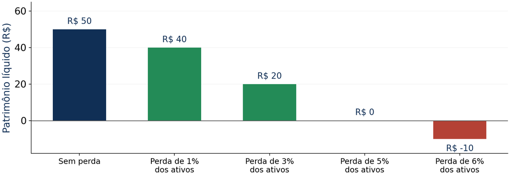

Efeito das perdas sobre o patrimônio de um banco com R$ 1.000 de ativos e R$ 50 de capital inicial.

O mesmo mecanismo pode ampliar o retorno sobre o capital quando há ganhos. A alavancagem exige cuidado porque a margem de absorção de perdas é pequena em relação aos ativos.

← Menu

## 41 - Como uma perda pode contrair o crédito

Após uma perda de R$ 20, o banco fica com ativos de R$ 980 e patrimônio de R$ 30. Sua alavancagem sobe para aproximadamente 32,7.

Se pretende retornar à razão 20, mantendo esse patrimônio, seus ativos teriam de cair para $20\times30=R\$\ 600$.

Uma perda inicial relativamente pequena pode, assim, provocar grande ajuste de balanço. O banco também pode buscar novo capital; não precisa necessariamente realizar todo o ajuste pela redução de ativos.

Vendas de ativos e restrição de empréstimos, quando generalizadas, podem pressionar preços e atividade. Esse mecanismo ajuda a compreender a discussão do capítulo sobre a crise financeira de 2008.

← Menu

## 42 - Falta de liquidez e insolvência

| Situação | Problema central | Exemplo |
| --- | --- | --- |
| Iliquidez | Falta de meios de pagamento no momento necessário | Bons empréstimos vencem em dois anos, mas saques ocorrem hoje |
| Insolvência | Ativos insuficientes para cobrir obrigações | Perdas permanentes superam o capital |

Um empréstimo temporário de liquidez pode ajudar uma instituição viável a enfrentar um desencontro de prazos. Ele não resolve, sozinho, um buraco patrimonial definitivo.

Vender ativos às pressas pode transformar um problema de liquidez em perda de patrimônio. Essa interação justifica atenção à qualidade dos ativos, à estrutura de financiamento e à confiança dos depositantes.

← Menu

## 43 - Corrida bancária: decisões individuais, risco coletivo

Depósitos podem ser sacados rapidamente, enquanto empréstimos vencem ao longo de meses ou anos. Se muitos clientes acreditam que outros sacarão, cada um pode tentar retirar seus recursos primeiro.

Uma instituição pode não conseguir liquidar todos os ativos imediatamente a um preço adequado. A venda forçada agrava perdas e pode contaminar outras instituições.

No modelo monetário, saques aumentam a preferência por numerário e pressionam reservas. No sistema real, a resposta depende de confiança, financiamento, assistência de liquidez e mecanismos de resolução.

**Conexão com microeconomia:** há problema de coordenação e externalidades. O comportamento prudente para um indivíduo pode agravar o risco do conjunto.

← Menu

## 44 - Proteção de depósitos e seus limites

O **Fundo Garantidor de Créditos, FGC**, é uma associação privada sem fins lucrativos. Sua proteção se aplica a créditos elegíveis e instituições associadas, segundo as regras do mecanismo.

A regra geral consultada prevê até **R$ 250 mil por CPF ou CNPJ, por instituição ou conglomerado**, com teto global de **R$ 1 milhão em quatro anos**, nas condições regulamentares.

A garantia pode reduzir o incentivo a corridas, mas não cobre qualquer produto nem elimina todos os riscos. Também pode reduzir a vigilância dos depositantes, criando risco moral.

Por isso, proteção, supervisão, capital e gestão de riscos precisam ser considerados em conjunto. Não se deve transportar automaticamente para o Brasil o modelo institucional americano de seguro de depósitos.

Fontes: [FGC, quem somos](https://www.fgc.org.br/quem-somos) e [garantia](https://www.fgc.org.br/pt-br/sobre-garantia-fgc). Consulta: 06/11/2026.

← Menu

## 45 - Os instrumentos: quantidade, custo e condições

| Instrumento | Canal imediato no modelo |
| --- | --- |
| Operações de mercado aberto | Acrescentam ou retiram liquidez mediante transações com títulos |
| Recolhimentos compulsórios | Alteram exigências de recursos recolhidos sobre bases específicas |
| Empréstimos de liquidez e redesconto | Fornecem liquidez às instituições sob condições definidas |
| Remuneração e depósitos no BCB | Alteram incentivos e permitem absorção de liquidez |

No Brasil, o centro operacional da política monetária é a **meta Selic**. Os instrumentos não são botões independentes que geram uma expansão previsível e automática de M1.

Fonte: [BCB, política monetária](https://www.bcb.gov.br/meubc/faqs/p/politicamonetariadobancocentral).

← Menu

## 46 - Mercado aberto: compra e venda de títulos

Em uma compra definitiva de títulos pelo BCB, com pagamento por criação de reservas, aumenta a liquidez bancária. Na venda, o pagamento ao BCB retira reservas.

| Operação do BCB | Reservas bancárias, demais fatores constantes |
| --- | --- |
| Compra de título | Aumentam |
| Venda de título | Diminuem |

**Perspectiva importa:** compra pelo BCB é venda pela contraparte. Observe sempre quem está comprando.

O efeito de retirada de liquidez tende a pressionar para cima os juros de curtíssimo prazo em um modelo de escassez de reservas. Na implementação real, também importam a remuneração de saldos e a comunicação da meta.

← Menu

## 47 - Comprar de um banco ou do público muda o efeito

O BCB compra R$ 100 em títulos. Compare os lançamentos iniciais:

| Vendedor | Efeito no banco | Efeito inicial em M1 |
| --- | --- | --- |
| O próprio banco | Títulos −100; reservas +100 | Não aumenta automaticamente |
| Um agente não bancário, com crédito em conta à vista | Reservas +100; depósito do vendedor +100 | Aumenta 100 no exemplo |

Nos dois casos, a base pode aumentar. Apenas no segundo há criação imediata do depósito indicado no enunciado.

Esta comparação não inclui eventuais operações compensatórias do BCB nem decisões posteriores dos agentes. **O resultado depende da sequência completa de transações.**

← Menu

## 48 - Operações compromissadas têm reversão prevista

Uma compromissada combina uma transação com títulos e o compromisso de realizar a operação inversa em uma data e a condições acordadas.

Quando o BCB **vende com compromisso de recomprar**, absorve liquidez hoje e a devolve na reversão, consideradas as condições financeiras. Quando compra com compromisso de revender, fornece liquidez temporária.

Não confunda uma operação temporária com uma alteração definitiva do estoque de títulos. Renovações e vencimentos também afetam a liquidez de cada dia.

Essas operações ajudam a ajustar o mercado de reservas. Usar títulos do Tesouro como instrumento monetário não transforma a operação em gasto orçamentário.

← Menu

## 49 - Selic meta, Selic efetiva e custo do crédito

**Selic meta:** taxa definida pelo Copom. **Selic efetiva:** taxa apurada em operações de financiamento de curtíssimo prazo com títulos públicos federais como garantia, no âmbito correspondente.

O BCB administra a liquidez para manter a taxa de mercado próxima da meta. A decisão do Copom não fixa administrativamente todos os juros cobrados de famílias e empresas.

O custo final de um empréstimo inclui custos de captação, risco, tributos, despesas, capital e margem. Por isso, ele pode ser muito superior à Selic.

A taxa DI, associada a depósitos interfinanceiros, tem formação própria. Pode ficar próxima da Selic, mas não é a mesma definição estatística ou o próprio instrumento de decisão do Copom.

Fontes: [BCB, taxa Selic](https://www.bcb.gov.br/controleinflacao/taxaselic) e [glossário, taxa DI](https://www.bcb.gov.br/acessoinformacao/glossario).

← Menu

## 50 - Decisão de política e ajuste diário de liquidez

O Copom pode manter a meta Selic e, ainda assim, o BCB precisar fornecer ou retirar reservas durante o período.

Pagamentos do Tesouro, arrecadação, saques de numerário, operações cambiais e vencimentos de títulos afetam a liquidez. Operações compensatórias evitam que esses movimentos afastem o juro de sua meta.

**Uma compra de títulos observada isoladamente não prova uma mudança de orientação da política.** Ela pode apenas neutralizar uma retirada de liquidez produzida por outro fator.

Para interpretar a política, combine decisão de juros, condições de liquidez, comunicação e contexto. O objetivo operacional não é deixar M1 crescer a uma proporção rígida da base.

← Menu

## 51 - Compulsório: obrigação de recolhimento

O recolhimento compulsório exige que instituições mantenham recursos segundo regras incidentes sobre determinadas obrigações. As bases, deduções e formas de remuneração variam entre modalidades.

No modelo simples, elevar o coeficiente obrigatório, mantendo os demais parâmetros, reduz a expansão possível de depósitos. Reduzi-lo libera capacidade potencial de liquidez.

Na prática, a liberação pode ser usada para crédito, compra de ativos, pagamento de obrigações ou reforço de liquidez. A escolha depende de demanda, risco, capital e custo.

**Não use o coeficiente hipotético de 20% como descrição da regulação brasileira.** Não há uma única alíquota que represente todos os depósitos e todas as instituições.

Fonte: [BCB, recolhimentos compulsórios](https://www.bcb.gov.br/estabilidadefinanceira/recolhimentoscompulsorios).

← Menu

## 52 - Liquidez do Banco Central e redesconto

O BCB pode fornecer liquidez a instituições financeiras mediante instrumentos e condições próprias, incluindo garantias e critérios de acesso. O redesconto é uma dessas referências institucionais.

No balanço simplificado, o banco recebe reservas e assume uma obrigação com o BCB. No BCB, surge um crédito contra o banco e uma obrigação de reservas.

Reduzir o custo de acesso tende, no modelo, a tornar essa liquidez mais atraente. Mas o resultado depende de garantias, regras, necessidade e decisão das instituições.

**Assistência de liquidez não é perdão da dívida nem solução automática para insolvência.** A função de emprestador de última instância busca conter problemas de liquidez e contágio em condições específicas.

Fonte: [BCB, instrumentos de política monetária](https://www.bcb.gov.br/meubc/faqs/p/politicamonetariadobancocentral).

← Menu

## 53 - Remuneração das reservas e depósitos voluntários

Se um saldo mantido no Banco Central é remunerado, sua taxa influencia o custo de oportunidade de outras aplicações. A atratividade de conceder crédito depende do retorno esperado, ajustado por risco e custos, em comparação com alternativas.

No Brasil, os **depósitos voluntários remunerados** são um instrumento de absorção de liquidez. São distintos dos recolhimentos obrigatórios e não exigem a mesma estrutura de uma compromissada com títulos.

A categoria didática “reservas” simplifica rubricas que possuem tratamentos estatísticos e regulatórios próprios. Não se deve transportar diretamente a remuneração de reservas do Federal Reserve para o BCB.

Fonte: [BCB, instrumentos da política monetária](https://www.bcb.gov.br/meubc/faqs/p/politicamonetariadobancocentral).

← Menu

## 54 - Reservas internacionais e esterilização

Em uma compra de divisas pelo BCB, paga em reais por crédito de reservas bancárias, os ativos externos e as obrigações monetárias do BCB aumentam.

Se o BCB desejar neutralizar esse efeito de liquidez, pode realizar uma operação de absorção. Essa compensação é chamada **esterilização**.

Exemplo: compra de divisas injeta R$ 100 milhões; venda de títulos retira R$ 100 milhões. O efeito líquido sobre as reservas, nesse exemplo, é zero.

Comprar moeda estrangeira tende, isoladamente, a pressionar sua cotação para cima em reais. Isso não favorece automaticamente importadores: a depreciação do real encarece compras externas. O resultado efetivo depende do restante do mercado.

← Menu

## 55 - Política monetária e política fiscal

| Decisão | Natureza principal |
| --- | --- |
| Alterar impostos e gastos orçamentários | Fiscal |
| Definir a meta Selic e administrar liquidez | Monetária |
| Alterar regras prudenciais dos bancos | Regulatória ou macroprudencial |

As políticas interagem, mas não são sinônimas. Financiar o orçamento, realizar pagamentos públicos e operar títulos no mercado secundário são operações diferentes.

Uma mudança nas condições de crédito habitacional determinada por regra financeira não se torna política fiscal apenas porque pode estimular a construção.

**Conexão com as próximas aulas:** juros influenciam investimento, consumo financiado e decisões de carteira; gastos e tributos afetam diretamente a demanda e a renda disponível.

← Menu

## 56 - Da Selic às decisões de famílias e empresas

Uma elevação da meta tende a aumentar o custo de financiamento e tornar aplicações financeiras mais atraentes. Alguns projetos de investimento e compras a prazo deixam de compensar.

A demanda pode desacelerar, afetando produção e emprego no curto prazo. Câmbio, preços de ativos e expectativas também participam da transmissão.

O efeito sobre a inflação ocorre com defasagens e depende do tipo de choque. Juros não produzem chuva, não reabrem instantaneamente uma estrada e não eliminam um gargalo de energia.

**Conexão com microeconomia:** decisões respondem a custos de oportunidade e incentivos. **Conexão com macroeconomia:** o conjunto dessas decisões altera demanda agregada, produto e preços.

← Menu

## 57 - Por que o controle monetário é imperfeito?

O Banco Central influencia fortemente o ambiente monetário, mas não escolhe sozinho todos os depósitos e empréstimos.

O público decide entre numerário e outros ativos; bancos decidem sobre risco e liquidez; empresas e famílias avaliam crédito; pagamentos públicos e externos alteram reservas.

Uma expansão de base pode coexistir com cautela bancária. Uma queda de M1 pode refletir migração para aplicações, sem redução equivalente do patrimônio ou da capacidade de gasto.

Por isso, a avaliação combina juros, crédito, agregados, atividade, preços e condições financeiras. O modelo do multiplicador esclarece relações, mas não substitui o diagnóstico institucional e empírico.

← Menu

## 58 - Revisão dos efeitos, com hipóteses explícitas

| Mudança isolada | Efeito inicial típico | Cuidado |
| --- | --- | --- |
| BCB compra títulos, creditando reservas | Aumenta base | M1 depende da contraparte |
| BCB vende títulos, recebendo reservas | Reduz base | Pode compensar outra injeção |
| Coeficiente de reservas aumenta | Reduz $m$ no modelo | Crédito não tem resposta mecânica |
| Público aumenta $P/D$ | Reduz $m$, se $r<1$ | Demanda por moeda pode mudar |
| Banco concede crédito em conta | Cria depósito | Exige gestão de risco, capital e liquidez |
| Devedor amortiza principal com depósito | Reduz crédito e depósito | Não confundir principal com juros |

Os efeitos são condicionais. Identifique sempre a operação, o setor, o momento e as variáveis mantidas constantes.

← Menu

## 59 - Um caso para conectar os conceitos

Uma pequena indústria deseja R$ 200 mil para comprar uma máquina. O banco aprova o crédito e cria um depósito. A empresa paga o fornecedor em outro banco, exigindo liquidação entre instituições.

O banco precisa avaliar a capacidade de pagamento da indústria, o retorno esperado, seu capital e seu financiamento. A alta da Selic pode encarecer a operação e tornar o projeto menos atraente.

Se a máquina elevar a produtividade, o crédito terá ajudado a financiar produção. Se a dívida não for paga, o banco reconhecerá perdas, afetando seu patrimônio.

**Acompanhe quatro registros:** depósito da empresa, crédito do banco, reservas na liquidação e patrimônio que absorve eventual perda. Cada um responde a uma pergunta distinta.

← Menu

## 60 - Conclusão: moeda, crédito e confiança

A moeda reduz custos de transação, mede valores e transfere poder de compra. Sua utilidade depende de aceitação e estabilidade, não apenas do material das notas.

Bancos criam moeda escritural ao conceder crédito e a destroem na amortização. Essa capacidade é limitada por liquidez, capital, risco, regulação e demanda.

O multiplicador mostra como base, depósitos e numerário se relacionam sob hipóteses definidas. No Brasil, o BCB opera principalmente por meio da meta Selic e da administração da liquidez.

**O sistema monetário é uma infraestrutura da vida econômica:** permite pagar salários, financiar produção e organizar compromissos. Compreendê-lo exige olhar simultaneamente para balanços, incentivos e consequências sociais.

← Menu

## Exercícios de concursos públicos

**12 questões reais:** seis de múltipla escolha e seis de julgamento. Nos itens C/E, marque **C (certo)** ou **E (errado)**. Os enunciados estão sintetizados para uso didático, preservando o conteúdo avaliado e o gabarito oficial. As resoluções são autorais.

Leia as questões antes de abrir as respostas. Esta página possui rolagem vertical.

### Questão 01

FGV, CGE/SC, Auditor do Estado, Economia, 2023, tipo 2, tarde, questão 8

A função de unidade de conta da moeda corresponde a:

1. Eliminar a dupla coincidência de interesses.
2. Fazer compras e vendas ocorrerem simultaneamente.
3. Oferecer um padrão para expressar os valores dos bens.
4. Exigir $n(n-1)/2$ preços entre $n$ mercadorias.
5. Preservar poder de compra ao longo do tempo.

Redação sintetizada para uso didático; estrutura de alternativas, dados e gabarito preservados.

[Prova original](https://conhecimento.fgv.br/sites/default/files/concursos/cns205_-_auditor_do_estado_-_economia_tardecns205_tipo_2.pdf) · [Gabarito oficial definitivo](https://conhecimento.fgv.br/sites/default/files/concursos/cgesc2022_gabarito_definitivo_retificado_20230327.pdf)

Resposta comentada

### Questão 02

FGV, ALE/GO, Analista Legislativo, Economista, 2026, tipo 1, questão 67

Qual foi a função central da URV na transição para o real?

1. Substituir imediatamente o cruzeiro real por moeda física.
2. Tornar-se o meio final de pagamento antes do real.
3. Financiar automaticamente o déficit por emissão indexada.
4. Fixar permanentemente o câmbio e dispensar política monetária.
5. Expressar preços, mantendo pagamentos em cruzeiros reais pela conversão diária.

Redação sintetizada; omitida a indicação de mês inicial do enunciado original. Na exposição histórica da aula, a URV é situada de março a junho de 1994. Alternativas e resposta preservadas.

[Prova original](https://conhecimento.fgv.br/sites/default/files/concursos/analista-legislativo-economista-cns207-tipo-1.pdf) · [Gabarito oficial definitivo](https://conhecimento.fgv.br/sites/default/files/concursos/gabarito-definitivo-ale-go.pdf)

Resposta comentada

### Questão 03

FGV, CGE/SC, Auditor do Estado, Economia, 2023, tipo 2, tarde, questão 1

O numerário do público é igual aos depósitos à vista. As reservas bancárias representam 60% desse numerário. Qual é o multiplicador monetário?

1. 0,9
2. 1
3. 1,1
4. 1,25
5. 1,43

Redação sintetizada para uso didático; estrutura de alternativas, dados e gabarito preservados.

[Prova original](https://conhecimento.fgv.br/sites/default/files/concursos/cns205_-_auditor_do_estado_-_economia_tardecns205_tipo_2.pdf) · [Gabarito oficial definitivo](https://conhecimento.fgv.br/sites/default/files/concursos/cgesc2022_gabarito_definitivo_retificado_20230327.pdf)

Resposta comentada

### Questão 04

FGV, CGE/SC, Auditor do Estado, Economia, 2023, tipo 2, tarde, questão 7

Julgue V/F: o BCB administra reservas internacionais; exerce funções de emissão, reservas bancárias, liquidez e controle monetário; reduzir a taxa de redesconto diminui a oferta de moeda por estimular reservas.

1. V, V, V
2. V, V, F
3. V, F, V
4. F, F, V
5. F, V, F

Redação sintetizada para uso didático; estrutura de alternativas, dados e gabarito preservados.

[Prova original](https://conhecimento.fgv.br/sites/default/files/concursos/cns205_-_auditor_do_estado_-_economia_tardecns205_tipo_2.pdf) · [Gabarito oficial definitivo](https://conhecimento.fgv.br/sites/default/files/concursos/cgesc2022_gabarito_definitivo_retificado_20230327.pdf)

Resposta comentada

### Questão 05

FGV, ALE/GO, Analista Legislativo, Economista, 2026, tipo 1, questão 64

Qual operação, no mecanismo descrito pela questão, ajuda a elevar o juro de mercado em direção a uma meta Selic maior?

1. Vender títulos e retirar reservas.
2. Comprar títulos e aumentar reservas.
3. Comprar títulos porque maior liquidez eleva os juros.
4. Manter a liquidez, pois a taxa é fixada diretamente por decreto.
5. Ampliar a liquidez para aumentar o custo interbancário.

Redação sintetizada para uso didático; estrutura de alternativas, dados e gabarito preservados.

[Prova original](https://conhecimento.fgv.br/sites/default/files/concursos/analista-legislativo-economista-cns207-tipo-1.pdf) · [Gabarito oficial definitivo](https://conhecimento.fgv.br/sites/default/files/concursos/gabarito-definitivo-ale-go.pdf)

Resposta comentada

### Questão 06

FGV, ALE/AM, Analista Legislativo, Economista, 2025, tipo 1, questão 70

No regime brasileiro de metas para a inflação, assinale a correta.

1. O BCB determina administrativamente todos os juros bancários.
2. O CMN define diariamente a meta Selic.
3. A política usa metas de base, sem anunciar meta de juros.
4. O Copom anuncia a meta Selic e o BCB ajusta reservas por operações de mercado aberto.
5. O BCB não pode intervir na formação da Selic.

Redação sintetizada para uso didático; estrutura de alternativas, dados e gabarito preservados.

[Prova original](https://conhecimento.fgv.br/sites/default/files/concursos/analista-legislativo-economista-cns309-tipo-1.pdf) · [Gabarito oficial definitivo](https://conhecimento.fgv.br/sites/default/files/concursos/gabarito-definitivo-ale-am.pdf)

Resposta comentada

### Questão 07

CESPE/UnB, Senado Federal, Consultor Legislativo, Área 14, 2002, questão 60, item 1

Emissão de moeda, redesconto, administração das reservas cambiais, fiscalização das bolsas de valores e regulação do crédito e dos juros são todas funções do BCB.

**( ) C ( ) E**

Redação sintetizada para uso didático; estrutura de alternativas, dados e gabarito preservados.

[Prova original](https://cdn.cebraspe.org.br/concursos/_antigos/2002/senado/Arquivos/area_14_LEGISL_1Et.pdf) · [Gabarito oficial definitivo](https://cdn.cebraspe.org.br/concursos/_antigos/2002/senado/Arquivos/Gab_Def-SENADO.pdf)

Resposta comentada

### Questão 08

CESPE/UnB, Senado Federal, Consultor Legislativo, Área 14, 2002, questão 60, item 2

A inflação estimula a poupança doméstica porque eleva a taxa líquida de retorno das aplicações financeiras.

**( ) C ( ) E**

Redação sintetizada para uso didático; estrutura de alternativas, dados e gabarito preservados.

[Prova original](https://cdn.cebraspe.org.br/concursos/_antigos/2002/senado/Arquivos/area_14_LEGISL_1Et.pdf) · [Gabarito oficial definitivo](https://cdn.cebraspe.org.br/concursos/_antigos/2002/senado/Arquivos/Gab_Def-SENADO.pdf)

Resposta comentada

### Questão 09

CESPE/UnB, Senado Federal, Consultor Legislativo, Área 14, 2002, questão 60, item 3

Reduzir a razão reservas/depósitos eleva o multiplicador monetário e contribui para expandir o estoque de moeda.

**( ) C ( ) E**

Redação sintetizada para uso didático; estrutura de alternativas, dados e gabarito preservados.

[Prova original](https://cdn.cebraspe.org.br/concursos/_antigos/2002/senado/Arquivos/area_14_LEGISL_1Et.pdf) · [Gabarito oficial definitivo](https://cdn.cebraspe.org.br/concursos/_antigos/2002/senado/Arquivos/Gab_Def-SENADO.pdf)

Resposta comentada

### Questão 10

CESPE/Cebraspe, TCE/PA, Auditor de Controle Externo, Fiscalização, Economia, 2016, item 81

Depósitos realizados pelas instituições financeiras no Banco Central constituem política monetária contracionista.

**( ) C ( ) E**

Redação sintetizada para uso didático; estrutura de alternativas, dados e gabarito preservados.

[Prova original](https://cdn.cebraspe.org.br/concursos/TCE_PA_16/arquivos/251TCEPA_027_01.pdf) · [Gabarito oficial definitivo](https://cdn.cebraspe.org.br/concursos/TCE_PA_16/arquivos/Gab_Definitivo_251TCEPA_027_01.pdf)

Resposta comentada

### Questão 11

CESPE/Cebraspe, TCE/PA, Auditor de Controle Externo, Fiscalização, Economia, 2016, item 82

Ao comprar divisas, o BCB favorece importadores porque reduz o preço em reais dos produtos importados.

**( ) C ( ) E**

Redação sintetizada para uso didático; estrutura de alternativas, dados e gabarito preservados.

[Prova original](https://cdn.cebraspe.org.br/concursos/TCE_PA_16/arquivos/251TCEPA_027_01.pdf) · [Gabarito oficial definitivo](https://cdn.cebraspe.org.br/concursos/TCE_PA_16/arquivos/Gab_Definitivo_251TCEPA_027_01.pdf)

Resposta comentada

### Questão 12

CESPE/Cebraspe, TCE/PA, Auditor de Controle Externo, Fiscalização, Economia, 2016, item 83

Autorizar o cumprimento de exigências de encaixe da poupança mediante financiamentos habitacionais caracteriza política fiscal expansionista.

**( ) C ( ) E**

Redação sintetizada para uso didático; estrutura de alternativas, dados e gabarito preservados.

[Prova original](https://cdn.cebraspe.org.br/concursos/TCE_PA_16/arquivos/251TCEPA_027_01.pdf) · [Gabarito oficial definitivo](https://cdn.cebraspe.org.br/concursos/TCE_PA_16/arquivos/Gab_Definitivo_251TCEPA_027_01.pdf)

Resposta comentada

**Gabarito resumido e resoluções comentadas**

| Questão | 01 | 02 | 03 | 04 | 05 | 06 | 07 | 08 | 09 | 10 | 11 | 12 |
| --- | --- | --- | --- | --- | --- | --- | --- | --- | --- | --- | --- | --- |
| Resposta | C | E | D | B | A | D | E | E | C | C | E | E |

**Questão 01: C**

A unidade de conta fornece uma escala comum para preços e obrigações. Eliminar a dupla coincidência está ligado ao meio de troca; preservar poder de compra corresponde à reserva de valor. O número de relações bilaterais descreve a comparação sem uma unidade comum, não a vantagem da moeda. A moeda também permite separar compra e venda no tempo.

Voltar ao enunciado

**Questão 02: E**

A URV funcionava como unidade de conta. O pagamento ainda se realizava em cruzeiros reais, pela cotação correspondente. O caso mostra que as funções monetárias podem ser separadas durante uma transição. As demais alternativas atribuem à URV uma circulação física, um financiamento automático ou um regime cambial permanente que não definem seu papel.

Voltar ao enunciado

**Questão 03: D**

Como $P=D$, temos $c=P/D=1$. Como $R/P=0{,}6$ e $P=D$, resulta $r=R/D=0{,}6$. Portanto, $m=(1+c)/(c+r)=2/1{,}6=1{,}25$. Outra solução: tome $P=D=100$ e $R=60$. Então $M_1=200$, $B=160$ e $M_1/B=1{,}25$. Não se aplica $1/r$, pois o público mantém numerário.

Voltar ao enunciado

**Questão 04: B**

As duas primeiras proposições descrevem atribuições do BCB. A terceira inverte o efeito esperado no modelo: acesso menos caro à liquidez tende a facilitar seu uso, não a produzir necessariamente contração monetária. A interpretação é condicional. No funcionamento brasileiro, a resposta também depende de regras, garantias, demanda e condições financeiras.

Voltar ao enunciado

**Questão 05: A**

A venda recebe reservas como pagamento e retira liquidez, pressionando o juro no mecanismo de mercado descrito. B faz o movimento oposto; C e E invertem a relação proposta; D ignora a implementação da meta. Isso não significa que toda decisão real de elevar a Selic exija uma queda observável de igual direção na base: remuneração de saldos e operações compensatórias também importam.

Voltar ao enunciado

**Questão 06: D**

A decisão sobre a meta Selic é do Copom; a implementação envolve gestão da liquidez pelo BCB. O CMN fixa a meta de inflação, não uma meta diária de juros. As taxas dos empréstimos dependem também de risco, custos e condições de mercado. O regime não se caracteriza por uma meta rígida de base monetária.

Voltar ao enunciado

**Questão 07: E**

A inclusão da fiscalização das bolsas de valores torna o conjunto incorreto: a supervisão do mercado de valores mobiliários corresponde à CVM em seu âmbito de competência. Ter atribuições monetárias e bancárias não faz do BCB o único supervisor de todos os mercados financeiros. Atenção a listas em que quase todos os elementos estão corretos. Fonte complementar: [CVM, mandato legal](https://www.gov.br/cvm/pt-br/acesso-a-informacao-cvm/institucional/competencia).

Voltar ao enunciado

**Questão 08: E**

Inflação maior não garante rendimento nominal maior nem retorno real maior. Mantido o rendimento nominal, a alta dos preços reduz o ganho em poder de compra. A decisão de poupar depende de renda, expectativas, juros reais e outras condições. O item atribui à inflação um efeito automático que não existe.

Voltar ao enunciado

**Questão 09: C**

No modelo, mantendo a base e a preferência por numerário, reduzir $r$ diminui o denominador de $m=(1+c)/(c+r)$ e eleva o multiplicador. Sem numerário, a relação é $m=1/r$. O gabarito corresponde à comparação condicional do modelo; não afirma que a expansão do crédito observado seja automática em qualquer conjuntura.

Voltar ao enunciado

**Questão 10: C**

O gabarito oficial é C, sob a interpretação de recolhimento ou aplicação no BCB que absorve liquidez disponível. É necessário explicitar essa leitura: a redação genérica não descreve qualquer crédito contábil em conta de reservas. Uma mera transferência entre contas de bancos, ou reservas criadas pelo próprio BCB, não representa necessariamente contração. A questão deve ser lida no contexto de instrumentos de absorção monetária.

Voltar ao enunciado

**Questão 11: E**

A compra de moeda estrangeira aumenta sua demanda e tende, isoladamente, a elevar sua cotação em reais. Isso significa depreciação da moeda doméstica, que encarece o produto importado de preço externo constante. Além disso, o efeito monetário da operação pode ser neutralizado por esterilização. A questão inverte a direção cambial esperada.

Voltar ao enunciado

**Questão 12: E**

O mecanismo descrito envolve exigibilidades financeiras e direcionamento de crédito. Não é uma decisão de gasto orçamentário ou tributação, portanto não se classifica como política fiscal apenas por estimular atividade. A distinção entre instrumentos fiscais, monetários e regulatórios permanece mesmo quando seus efeitos econômicos se relacionam.

Voltar ao enunciado

← Menu